# repdata2

Kent Mok

August 19, 2015

# Weather Events in the United States

## Synopsis

This analysis reviews storm data provided by the U. S. National Oceanic and Atmospheric Administration’s (NOAA) storm database. The database tracks characteristics of major storms and weather events in the United States, including when and where they occur, as well as estimates of any fatalities, injuries, and property damage. Using the data, this analysis determines which type of events are the most harmful to people by looking at fatalities and injuries related to the events. In addition, the analysis determines which type of events have the greatest economic consequences.

## Data Processing

```r
# Load data
rawdata <- read.csv("repdata-data-StormData.csv")
```

The data is quite messy as can be seen by looking at unique values of EVTYPE in the data. The data needs to be cleaned to match the standard Storm Data Event values set forth by the NWS.

```r
levels(rawdata$EVTYPE)
```

```
##   [1] "   HIGH SURF ADVISORY"          " COASTAL FLOOD"
##   [3] " FLASH FLOOD"                   " LIGHTNING"
##   [5] " TSTM WIND"                     " TSTM WIND (G45)"
##   [7] " WATERSPOUT"                    " WIND"
##   [9] "?"                              "ABNORMAL WARMTH"
##  [11] "ABNORMALLY DRY"                 "ABNORMALLY WET"
##  [13] "ACCUMULATED SNOWFALL"           "AGRICULTURAL FREEZE"
##  [15] "APACHE COUNTY"                  "ASTRONOMICAL HIGH TIDE"
##  [17] "ASTRONOMICAL LOW TIDE"          "AVALANCE"
##  [19] "AVALANCHE"                      "BEACH EROSIN"
##  [21] "Beach Erosion"                  "BEACH EROSION"
##  [23] "BEACH EROSION/COASTAL FLOOD"    "BEACH FLOOD"
##  [25] "BELOW NORMAL PRECIPITATION"     "BITTER WIND CHILL"
##  [27] "BITTER WIND CHILL TEMPERATURES" "Black Ice"
##  [29] "BLACK ICE"                      "BLIZZARD"
```

[output cut: 478 more lines]

The below code is used to clean the data based on event types.

```r
# Clean data
rawdata$EVTYPE[grep("HIGH SURF", rawdata$EVTYPE)] <- "HIGH SURF"
rawdata$EVTYPE[grep("HEAVY SURF", rawdata$EVTYPE, ignore.case = TRUE)] <-
    "HEAVY SURF"
rawdata$EVTYPE[grep("RIP CURRENT", rawdata$EVTYPE)] <- "RIP CURRENT"
# "Burst" included under Thunderstorm Wind per 7.39.1 of NWSI 10-1605
# According to the remarks column, all EVTYPE's beginning with SUMMARY were
# related to thunderstorms.
tstormmatch <- c("THUNDERSTORM WIND", "THUNDERSTORMS WIND",
                 "THUDERSTORM WINDS", "THUNDEERSTORM WINDS",
                 "THUNDERESTORM WINDS", "THUNDERSTORM  WINDS",
                 "THUNDERSTORM W INDS", "THUNDERSTORM WINS",
                 "THUNDERSTORMW WINDS", "THUNDERSTORMWINDS",
                 "THUNDERSTROM WIND", "THUNDERSTROM WINDS",
                 "THUNDERTORM WINDS", "THUNDERTSORM WIND",
                 "THUNDESTORM WINDS", "THUNERSTORM WINDS", "BURST",
                 "TUNDERSTORM WIND", "^Summary", "^TSTM", "^ TSTM")
rawdata$EVTYPE[grep(paste(tstormmatch, collapse = "|"), rawdata$EVTYPE,
    ignore.case = TRUE)] <- "THUNDERSTORM WIND"
rawdata$EVTYPE[grep("^FLASH", rawdata$EVTYPE)] <- "FLASH FLOOD"
rawdata$EVTYPE[grep("^FLOOD", rawdata$EVTYPE)] <- "FLOOD"
rawdata$EVTYPE[grep("WILD", rawdata$EVTYPE)] <- "WILDFIRE"
lightningmatch <- c("^LIGHTNING", "^ LIGHTNING", "RED FLAG CRITERIA")
rawdata$EVTYPE[grep(paste(lightningmatch, collapse = "|"), rawdata$EVTYPE)] <-
    "LIGHTNING"
rawdata$EVTYPE[grep("^HAIL", rawdata$EVTYPE)] <- "HAIL"
dustdevilmatch <- c("DUST DEVIL", "DUST DEVEL")
rawdata$EVTYPE[grep(paste(dustdevilmatch, collapse = "|"), rawdata$EVTYPE,
    ignore.case = TRUE)] <- "DUST DEVIL"
rawdata$EVTYPE[grep("VOLCANIC", rawdata$EVTYPE, ignore.case = TRUE)] <-
    "VOLCANIC ASH"
rawdata$EVTYPE[grep("^HEAVY SNOW", rawdata$EVTYPE, ignore.case = TRUE)] <-
    "HEAVY SNOW"
rawdata$EVTYPE[grep("HURRICANE", rawdata$EVTYPE, ignore.case = TRUE)] <-
    "HURRICANE/TYPHOON"
waterspoutmatch <- c("^WATERSPOUT", "^ WATERSPOUT", "WAYTERSPOUT",
                     "WATER SPOUT", "LANDSPOUT")
rawdata$EVTYPE[grep(paste(waterspoutmatch, collapse = "|"), rawdata$EVTYPE,
    ignore.case = TRUE)] <- "WATERSPOUT"
densefogmatch <- c("DENSEFOG", "^FOG")
rawdata$EVTYPE[grep(paste(densefogmatch, collapse = "|"), rawdata$EVTYPE,
    ignore.case = TRUE)] <- "DENSE FOG"
freezefogmatch <- c("FREEZING FOG", "ICE FOG")
rawdata$EVTYPE[grep(paste(freezefogmatch, collapse = "|"), rawdata$EVTYPE,
    ignore.case = TRUE)] <- "FREEZING FOG"
heavyrainmatch <- c("^HEAVY RAIN", "LOCALLY HEAVY RAIN", "TSTM HEAVY RAIN")
rawdata$EVTYPE[grep(paste(heavyrainmatch, collapse = "|"), rawdata$EVTYPE,
    ignore.case = TRUE)] <- "HEAVY RAIN"
# "Freezing drizzle" included under Winter Weather per 7.48 of NWSI 10-1605
# Also assuming that "Wintry" falls under this category
wintweatmatch <- c("WINTER WEATHER", "FREEZING DRIZZLE", "WINTERY", "WINTRY",
                   "WINTER MIX")
rawdata$EVTYPE[grep(paste(wintweatmatch, collapse = "|"), rawdata$EVTYPE,
    ignore.case = TRUE)] <- "WINTER WEATHER"
rawdata$EVTYPE[grep("TROPICAL STORM", rawdata$EVTYPE, ignore.case = TRUE)] <-
    "TROPICAL STORM"
# "Freezing rain" included under Winter Storm per 7.47 of NWSI 10-1605
# "Light snow" included under Winter Storm per 7.47 of NWSI 10-1605
wstormmatch <- c("^WINTER STORM", "^FREEZING RAIN", "LIGHT SNOW")
rawdata$EVTYPE[grep(paste(wstormmatch, collapse = "|"), rawdata$EVTYPE,
    ignore.case = TRUE)] <- "WINTER STORM"
rawdata$EVTYPE[grep("^STRONG WIND", rawdata$EVTYPE, ignore.case = TRUE)] <-
    "STRONG WIND"
# Since "High Winds" accompany blizzards, any event type with high wind and
# blizzard in it will be resolved to just "Blizzard"
rawdata$EVTYPE[grep("BLIZZARD", rawdata$EVTYPE, ignore.case = TRUE)] <-
    "BLIZZARD"
# Any event type with "Drought" resolved to just "Drought"
rawdata$EVTYPE[grep("DROUGHT", rawdata$EVTYPE, ignore.case = TRUE)] <-
    "DROUGHT"
excheatmatch <- c("EXCESSIVE HEAT", "EXTREME HEAT", "HEAT WAVE", "RECORD HEAT")
rawdata$EVTYPE[grep(paste(excheatmatch, collapse = "|"), rawdata$EVTYPE,
    ignore.case = TRUE)] <- "EXCESSIVE HEAT"
# "Unseasonably warm" included under Heat per 7.47 of NWSI 10-1605
heatmatch <- c("UNSEASONABLY WARM", "UNSEASONABLY HOT", "HEAT", "VERY WARM",
               "HOT", "RECORD WARM")
rawdata$EVTYPE[grep(paste(heatmatch, collapse = "|"), rawdata$EVTYPE,
    ignore.case = TRUE)] <- "HEAT"
extcoldmatch <- c("RECORD COLD", "RECORD  COLD", "WIND CHILL")
rawdata$EVTYPE[grep(paste(extcoldmatch, collapse = "|"), rawdata$EVTYPE,
    ignore.case = TRUE)] <- "EXTREME COLD/WIND CHILL"
# "Urban flooding" included under Flood per 7.14.4 of NWSI 10-1605
floodmatch <- c("URBAN", "STREAM")
rawdata$EVTYPE[grep(paste(floodmatch, collapse = "|"), rawdata$EVTYPE,
    ignore.case = TRUE)] <- "FLOOD"
coastalmatch <- c("COASTAL FLOOD", "COASTALFLOOD")
rawdata$EVTYPE[grep(paste(coastalmatch, collapse = "|"), rawdata$EVTYPE,
    ignore.case = TRUE)] <- "COASTAL FLOOD"
marineswmatch <- c("MARINE MISHAP")
rawdata$EVTYPE[grep(paste(marineswmatch, collapse = "|"), rawdata$EVTYPE,
    ignore.case = TRUE)] <- "MARINE STRONG WIND"
tornadomatch <- c("TORNADO", "TORNDAO")
rawdata$EVTYPE[grep(paste(tornadomatch, collapse = "|"), rawdata$EVTYPE,
    ignore.case = TRUE)] <- "TORNADO"
tidematch <- c("STORM SURGE", "^TIDAL")
rawdata$EVTYPE[grep(paste(tidematch, collapse = "|"), rawdata$EVTYPE,
    ignore.case = TRUE)] <- "STORM SURGE/TIDE"

rawdata$EVTYPE <- droplevels(rawdata$EVTYPE)
```

After cleaning, the unique values of event type looks as follows:

```r
levels(rawdata$EVTYPE)
```

```
##   [1] " FLASH FLOOD"                   " WIND"
##   [3] "?"                              "ABNORMAL WARMTH"
##   [5] "ABNORMALLY DRY"                 "ABNORMALLY WET"
##   [7] "ACCUMULATED SNOWFALL"           "AGRICULTURAL FREEZE"
##   [9] "APACHE COUNTY"                  "ASTRONOMICAL HIGH TIDE"
##  [11] "ASTRONOMICAL LOW TIDE"          "AVALANCE"
##  [13] "AVALANCHE"                      "BEACH EROSIN"
##  [15] "Beach Erosion"                  "BEACH EROSION"
##  [17] "BEACH FLOOD"                    "BELOW NORMAL PRECIPITATION"
##  [19] "Black Ice"                      "BLACK ICE"
##  [21] "BLIZZARD"                       "BLOW-OUT TIDE"
##  [23] "BLOW-OUT TIDES"                 "BLOWING DUST"
##  [25] "blowing snow"                   "Blowing Snow"
##  [27] "BLOWING SNOW"                   "BLOWING SNOW- EXTREME WIND CHI"
##  [29] "BLOWING SNOW & EXTREME WIND CH" "BLOWING SNOW/EXTREME WIND CHIL"
```

[output cut: 219 more lines]

## Results

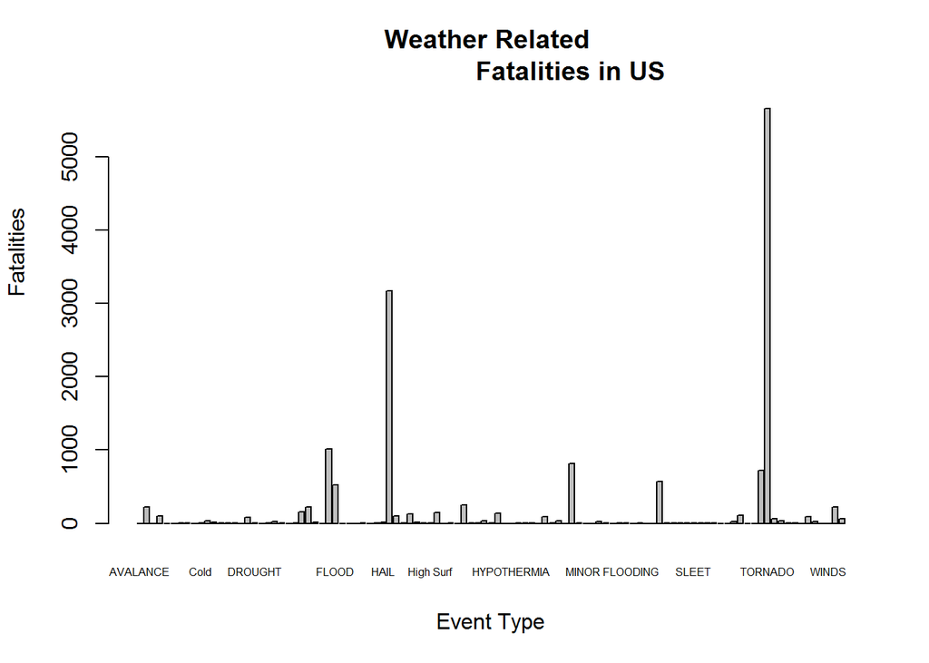

```r
# Split the total fatalities data by the event type.
fatalities <- aggregate(rawdata$FATALITIES, list(rawdata$EVTYPE), FUN = sum)
colnames(fatalities) <- c("EVTYPE", "FATALITIES")
# Extract data where fatalities are greater than zero.
nonzerofatals <- fatalities[fatalities$FATALITIES != 0,]
# Create a barplot of the extracted fatalities data.
plotfatal <- barplot(nonzerofatals$FATALITIES, main = "Weather Related
                     Fatalities in US", xlab = "Event Type", ylab = "Total
                     Fatalities", names.arg = nonzerofatals$EVTYPE,
                     cex.names = 0.5)
```

The plot above shows that the weather event with the most fatalities are tornadoes.

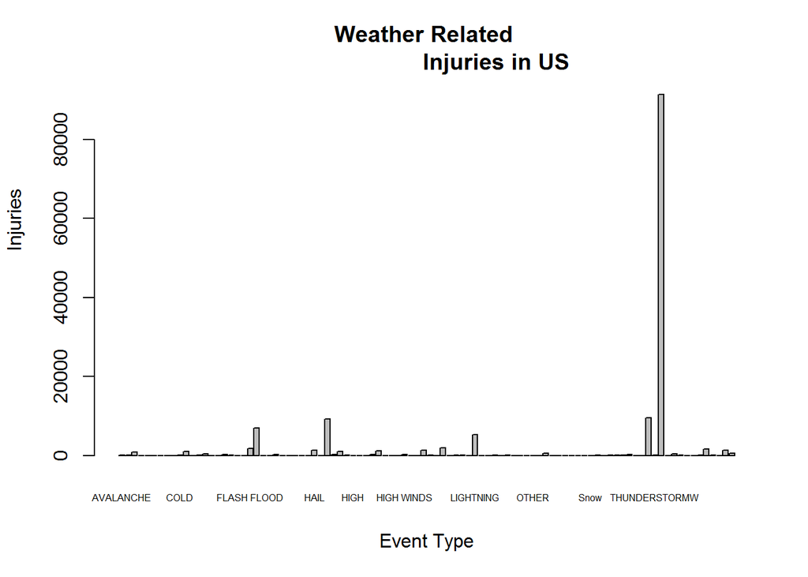

```r
# Split the total injuries data by the event type.
injuries <- aggregate(rawdata$INJURIES, list(rawdata$EVTYPE), FUN = sum)
colnames(injuries) <- c("EVTYPE", "INJURIES")
# Extract data where fatalities are greater than zero.
nonzeroinjurs <- injuries[injuries$INJURIES != 0,]
# Create a barplot of the extracted fatalities data.
plotinjur <- barplot(nonzeroinjurs$INJURIES, main = "Weather Related
                     Injuries in US", xlab = "Event Type", ylab = "Total
                     Injuries", names.arg = nonzeroinjurs$EVTYPE,
                     cex.names = 0.5)
```

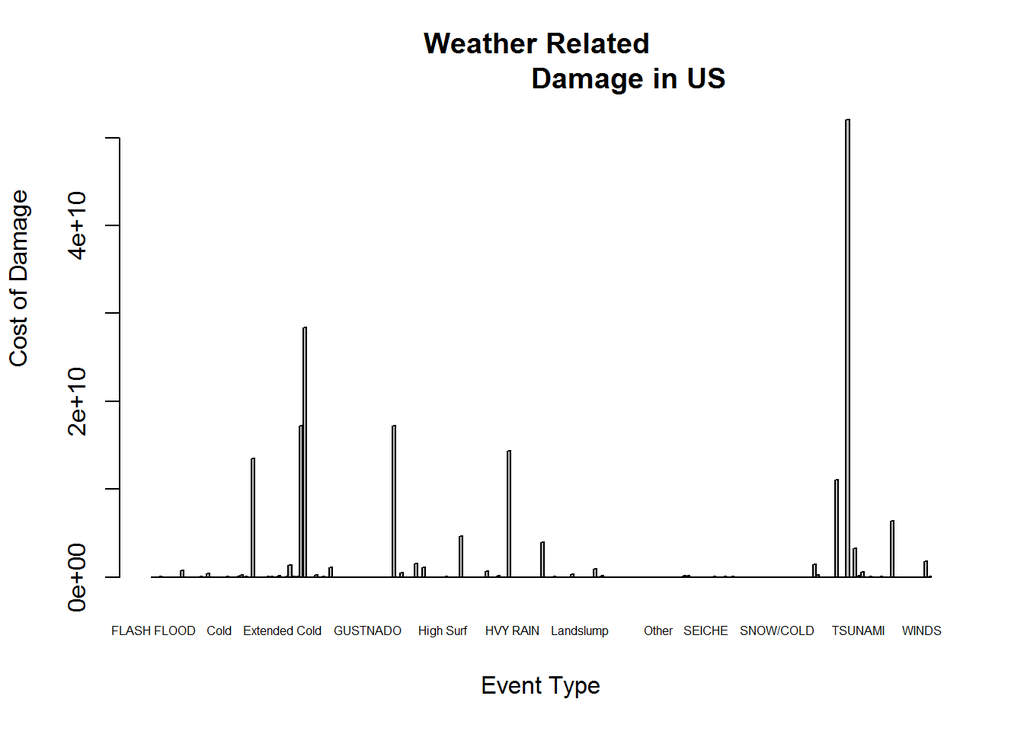

```r
# Copy property damage to a new total damage column
rawdata$TOTALDMG <- rawdata$PROPDMG

# Apply multipliers for the property damage
rawdata$TOTALDMG[rawdata$PROPDMGEXP == "H"] <- rawdata$TOTALDMG[rawdata$PROPDMGEXP == "H"] * 100
rawdata$TOTALDMG[rawdata$PROPDMGEXP == "K"] <- rawdata$TOTALDMG[rawdata$PROPDMGEXP == "K"] * 1000
rawdata$TOTALDMG[rawdata$PROPDMGEXP == "M"] <- rawdata$TOTALDMG[rawdata$PROPDMGEXP == "M"] * 1000000

# Add crop damage with multipliers to the total damage
rawdata$TOTALDMG[rawdata$CROPDMGEXP == "H"] <- rawdata$TOTALDMG[rawdata$CROPDMGEXP == "H"] +
    rawdata$CROPDMG[rawdata$CROPDMGEXP == "H"] * 100
rawdata$TOTALDMG[rawdata$CROPDMGEXP == "K"] <- rawdata$TOTALDMG[rawdata$CROPDMGEXP == "K"] +
    rawdata$CROPDMG[rawdata$CROPDMGEXP == "K"] * 1000
rawdata$TOTALDMG[rawdata$CROPDMGEXP == "M"] <- rawdata$TOTALDMG[rawdata$CROPDMGEXP == "M"] +
    rawdata$CROPDMG[rawdata$CROPDMGEXP == "M"] * 1000000

# Split the total damage cost data by the event type.
totaldamage <- aggregate(rawdata$TOTALDMG, list(rawdata$EVTYPE), FUN = sum)
colnames(totaldamage) <- c("EVTYPE", "TOTALDMG")
# Extract data where damage cost is greater than zero.
nonzerodamag <- totaldamage[totaldamage$TOTALDMG != 0,]
# Create a barplot of the extracted damage cost data.
plotdamag <- barplot(nonzerodamag$TOTALDMG, main = "Weather Related
                     Damage in US", xlab = "Event Type", ylab = "Total
                     Cost of Damage", names.arg = nonzerodamag$EVTYPE,
                     cex.names = 0.5)
```

The plot above shows that the weather event with the greatest total damage cost is tornadoes.